# R Notebook

```r
library(tidyverse)
library(infer)
library(janitor)
animal_data <- msleep
```

Question 1. Explore the dataset and familiarise yourself with it.

```r
animal_data
```

| name | genus | vore | order | conservation | sleep_total | sleep_rem | sleep_cycle | awake | brainwt | bodywt |
| --- | --- | --- | --- | --- | --- | --- | --- | --- | --- | --- |
| Cheetah | Acinonyx | carni | Carnivora | lc | 12.1 | NA | NA | 11.90 | NA | 50.000 |
| Owl monkey | Aotus | omni | Primates | NA | 17.0 | 1.8 | NA | 7.00 | 0.01550 | 0.480 |
| Mountain beaver | Aplodontia | herbi | Rodentia | nt | 14.4 | 2.4 | NA | 9.60 | NA | 1.350 |
| Greater short-tailed shrew | Blarina | omni | Soricomorpha | lc | 14.9 | 2.3 | 0.1333333 | 9.10 | 0.00029 | 0.019 |
| Cow | Bos | herbi | Artiodactyla | domesticated | 4.0 | 0.7 | 0.6666667 | 20.00 | 0.42300 | 600.000 |
| Three-toed sloth | Bradypus | herbi | Pilosa | NA | 14.4 | 2.2 | 0.7666667 | 9.60 | NA | 3.850 |
| Northern fur seal | Callorhinus | carni | Carnivora | vu | 8.7 | 1.4 | 0.3833333 | 15.30 | NA | 20.490 |
| Vesper mouse | Calomys | NA | Rodentia | NA | 7.0 | NA | NA | 17.00 | NA | 0.045 |
| Dog | Canis | carni | Carnivora | domesticated | 10.1 | 2.9 | 0.3333333 | 13.90 | 0.07000 | 14.000 |
| Roe deer | Capreolus | herbi | Artiodactyla | lc | 3.0 | NA | NA | 21.00 | 0.09820 | 14.800 |

[output cut: 73 more lines]

Question 2. Jabberwockies sleep for around 7 hours a night, on average. Perform an appropriate statistical test to determine whether the mean sleep_total in the sampled population of animal types differs from the typical value for jabberwockies.

[output not shown]

[output cut: 73 more lines]

simulate null situation

```r
null_distribution <- animal_data %>%
  specify(response = sleep_total) %>%
  hypothesise(null = "point", mu = 7) %>%
  generate(reps = 2000, type = "bootstrap") %>%
  calculate(stat = "mean")
```

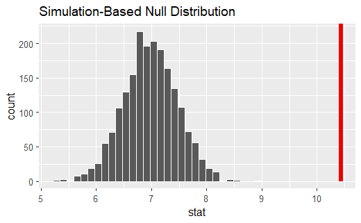

```r
null_distribution %>%
  visualise(bins = 30) +
  shade_p_value(obs_stat = mean_sleep, direction = "both")
```

```r
null_distribution %>%
  get_p_value(obs_stat = mean_sleep, "both")
```

| p_value |
| --- |
| 0 |

```r
# the p value is very close to 0 therefore we can reject the null hypothesis. In favour of the altenate hypothesis that jaberwocky sleep differs significantly from the mean sleep total of sampled animals
```

Question 3. Perform an appropriate statistical test to determine whether omnivores sleep for significantly longer than herbivores, on average.

alpha = 0.05 H0: omnivore_mean_sleep - herbivore_mean_sleep <= 0 HA: omnivore_mean_sleep - herbivore_mean_sleep > 0

```r
omni_herbi <- animal_data %>%
  filter(vore %in% c("omni", "herbi"))

# find observed stat, diff in means

diff_in_means_omni_herbi <- omni_herbi %>%
  specify(sleep_total ~ vore) %>%
  calculate(stat = "diff in means", order = c("omni", "herbi")) %>%
  pull()
```

```r
null_distribution <- omni_herbi %>%
  specify(response = sleep_total, explanatory = vore) %>%
  hypothesise(null = "independence") %>%
  generate(reps = 5000, type = "permute") %>%
  calculate(stat = "diff in means", order = c("omni", "herbi"))
```

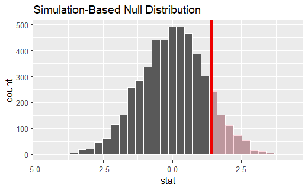

```r
null_distribution %>%
  visualise(bins = 30) +
  shade_p_value(obs_stat = diff_in_means_omni_herbi, direction = "right")
```

```r
null_distribution %>%
  get_p_value(obs_stat = diff_in_means_omni_herbi, "right")
```

| p_value |
| --- |
| 0.1186 |

```r
# p value is greater than alpha therefore we cannot reject the null hypothesis
```

Question 4. Perform an appropriate statistical test to determine whether the proportion of domesticated animal types in the population of animal types is greater than 5%.

alpha = 0.05 HO: prop_dom - 0.05 <= 0 HA: mean_dom - 0.05 > 0

```r
# having looked at the data set the NAs dont seem like domesticated animals so i will coalese to "No"

domestication_data <- animal_data %>%
  mutate(is_domesticated = if_else(conservation == "domesticated", "Yes", "No"),
         is_domesticated =  coalesce(is_domesticated, "No"))

domesticated_prop <- domestication_data %>%
  filter(is_domesticated == "Yes") %>%
  summarise(prop_french = n() / nrow(domestication_data)) %>%
  pull()
```

```r
# generate null distribution

null_distribution <- domestication_data %>%
  specify(response = is_domesticated, success = "Yes") %>%
  hypothesise(null = "point", p = 0.05) %>%
  generate(reps = 5000, type = "draw") %>%
  calculate(stat = "prop")
```

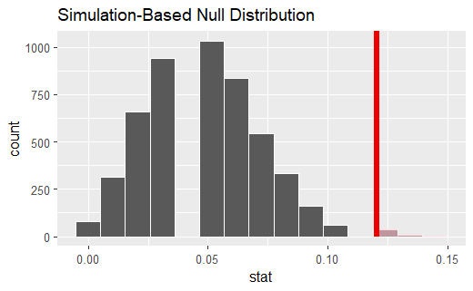

```r
## plot

null_distribution %>%
  visualise(bins = 15) +
  shade_p_value(obs_stat = domesticated_prop, direction = "right")
```

```r
null_distribution %>%
  get_p_value(obs_stat = domesticated_prop, "right")
```

| p_value |
| --- |
| 0.0092 |

```r
# p value is less than 0.05 therefore we can reject the null hypothesis in favour of the alternate hypothesis: proportion of domesticated animals is greater than 0.05
```

Question 1. You work for a independent coffee shop. The boss tells you that she thinks that around 40% of people in the town (population 30,000) know of the coffee shop, but you are skeptical of the estimate. You conduct a random survey of 200 people in the town, asking if respondents are aware of your coffee shop. You want to use the sample to test the hypothesis that **40% or more** of the town’s population have heard of the coffee shop.

Test type: 1 sample proportion

The question is written quite strangely - (40% or more - >= 40% this means that this has to H0 as HA cant have an = in it. Normally the question would say more, less or different so you would have a HA sign of >, < or !=0)

**My interpretation id that the question means to say that is the amount of people that have heard of the coffee shop greater than 40%**

H0: 40% or less of the town have heard of the coffee shop HA: more than 40% of the population of the town have heard of the coffee shop

H0: prop_have_heard - 0.4 <= 0.4 (or prop_have_heard - 0.4 = 0.4) **depending on preffered notation** HA: prop_have_heard - 0.4 > 0

Type = draw

Question 2.

**You work for a website design company and have performed an A/B test on the position of a banner on a website promoting a particular item.** **A/B testing A method comparing two versions of a web page, email, flyer or other marketing device against each other to determine which version performs better. As it is essentially a controlled experiment, the design should try to ensure that the groups experiencing both versions of the marketing device are equivalent and representative of the population.** **You selected five days at random last month and then randomly selected 200 of each sampled day’s users into group A and another 200 of that day’s users into group B. Group A continued to be shown the banner at the right hand side of the webpage (its usual position) while group B was shown the banner at the top of the page. You monitored each sampled user’s interactions with the website, in particular the ‘click through rate’ (CTR) on the banner, i.e. what proportion of sampled users clicked on the banner. You want to use the sampled data to test the hypothesis that website users overall are more likely to click on the banner if positioned at the top of the page**

Test type: 2 sample independent

H0: group b (banner at top) has a lower than or equal to CTR group a (RHS) HA: group b (banner at top) has a higher CTR than group a (RHS)

H0: group_b_mean_click_through_rate - group_a_mean_click_through_rate <= 0 HA: group_b_mean_click_through_rate - group_a_mean_click_through_rate > 0

Type = permute

Question 3. **You work as an analyst for a car manufacturing company - they have specific standards they must meet for standards and regulation purposes. You have been asked to check the quality control of the manufacture of a particular car part. You have been given data on a sample of 200 parts produced over the period of a week (the sampled parts were pulled at random from the production line and measured: the factory produced a lot more than 200 parts that week). The specification of the part stipulates a width of 145mm, and the manufacturing process is said to have ‘drifted’ if the mean width of parts differs significantly from 145mm. You want to use the sampled measurements to test whether the process overall has drifted.**

Test type: 1 sample mean

H0: width of car part has not drifted from 145mm HA: width of car part has drifted from 145mm

H0: mean_part_width - 145 == 0 HA: mean_part_width - 145 != 0

Type = bootstrap

**For the 3 business problems stated above, imagine we performed you got the following p-values (with the given significance levels) write out your interpretation of the results.**

**Question 1.**

**Coffee shop problem. Significance level: 0.05, calculated p-value: 0.07**

Cannot reject null hypothesis that 40% or fewer of the population have heard of the coffee shop

**Question 2.** **Website company problem. Significance level: 0.01, p-value: 0.006**

can reject the null hypothesis that an equal or smaller number of people clicked banner b infavour of the alternate hypothesis that more prople click banner b than banner a

**Question 3.** **Manufacturing company problem. Significance level: 0.05, p-value: 0.55**

cannot reject the null hypothesis that width has not driffted

```r
transactions <- read_csv(here::here("data/online_retail_subset.csv")) %>%
  clean_names()
```

| invoice_no | stock_code | description | invoice_date | unit_price | customer_id | country |
| --- | --- | --- | --- | --- | --- | --- |
| 536365 | 85123A | WHITE HANGING HEART T-LIGHT HOLDER | 12/1/10 8:26 | 2.55 | 17850 | United Kingdom |
| 536365 | 71053 | WHITE METAL LANTERN | 12/1/10 8:26 | 3.39 | 17850 | United Kingdom |
| 536365 | 84406B | CREAM CUPID HEARTS COAT HANGER | 12/1/10 8:26 | 2.75 | 17850 | United Kingdom |
| 536365 | 84029G | KNITTED UNION FLAG HOT WATER BOTTLE | 12/1/10 8:26 | 3.39 | 17850 | United Kingdom |
| 536365 | 84029E | RED WOOLLY HOTTIE WHITE HEART. | 12/1/10 8:26 | 3.39 | 17850 | United Kingdom |
| 536365 | 22752 | SET 7 BABUSHKA NESTING BOXES | 12/1/10 8:26 | 7.65 | 17850 | United Kingdom |
| 536365 | 21730 | GLASS STAR FROSTED T-LIGHT HOLDER | 12/1/10 8:26 | 4.25 | 17850 | United Kingdom |
| 536366 | 22633 | HAND WARMER UNION JACK | 12/1/10 8:28 | 1.85 | 17850 | United Kingdom |
| 536366 | 22632 | HAND WARMER RED POLKA DOT | 12/1/10 8:28 | 1.85 | 17850 | United Kingdom |
| 536367 | 84879 | ASSORTED COLOUR BIRD ORNAMENT | 12/1/10 8:34 | 1.69 | 13047 | United Kingdom |

[output cut: 10 more lines]

```r
total_transactions <- transactions %>%
  summarise(n = n_distinct(invoice_no)) %>%
  flatten_dbl()

support_a <- transactions %>%
  filter(stock_code == "22469") %>%
  summarise(suppor_a = n_distinct(invoice_no) / total_transactions) %>%
  pull()

support_b <- transactions %>%
  filter(stock_code == "21110") %>%
  summarise(suppor_b = n_distinct(invoice_no) / total_transactions) %>%
  pull()
```

```r
a_and_b <- transactions %>%
  filter(stock_code %in% c("22469", "21110")) %>%
  select(invoice_no, stock_code, unit_price) %>%
  pivot_wider(names_from = stock_code, values_from = unit_price) %>%
  unchop(everything()) %>%
  rename(a = '22469',
         b = '21110') %>%
  mutate(a_and_b = if_else(!is.na(a) & !is.na(b), TRUE, FALSE))
support_a_and_b <- a_and_b %>%
  filter(a_and_b == TRUE) %>%
  summarise(support_a_and_b = n() / total_transactions) %>%
  pull()

confidence <- support_a_and_b / support_a

lift <- support_a_and_b / (support_a * support_b)

# more likely to be bought together
```

```r
library(arules)
library(arulesViz)
transactions <- read_csv(here::here("data/online_retail_subset.csv"))
```

```r
transactions_reformat <- transactions %>%
  select(InvoiceNo, Description) %>%
  na.omit()

write_csv(transactions_reformat, here::here("data/transactions_reformat.csv"))

apriori_format <- read.transactions(here::here("data/transactions_reformat.csv"), format = "single", sep = ",", header = TRUE, cols = c("InvoiceNo", "Description"))
```

```r
inspect(head(apriori_format))
```

```
    items                                                        transactionID
[1] {CREAM CUPID HEARTS COAT HANGER,
     GLASS STAR FROSTED T-LIGHT HOLDER,
     KNITTED UNION FLAG HOT WATER BOTTLE,
     RED WOOLLY HOTTIE WHITE HEART.,
     SET 7 BABUSHKA NESTING BOXES,
     WHITE HANGING HEART T-LIGHT HOLDER,
     WHITE METAL LANTERN}                                               536365
[2] {HAND WARMER RED POLKA DOT,
     HAND WARMER UNION JACK}                                            536366
[3] {ASSORTED COLOUR BIRD ORNAMENT,
     BOX OF 6 ASSORTED COLOUR TEASPOONS,
     BOX OF VINTAGE ALPHABET BLOCKS,
     BOX OF VINTAGE JIGSAW BLOCKS,
     DOORMAT NEW ENGLAND,
     FELTCRAFT PRINCESS CHARLOTTE DOLL,
     HOME BUILDING BLOCK WORD,
     IVORY KNITTED MUG COSY,
     LOVE BUILDING BLOCK WORD,
     POPPYS PLAYHOUSE BEDROOM
536367,POPPYS PLAYHOUSE KITCHEN,
     RECIPE BOX WITH METAL HEART}                                       536367
[4] {BLUE COAT RACK PARIS FASHION,
     JAM MAKING SET WITH JARS,
     RED COAT RACK PARIS FASHION,
     YELLOW COAT RACK PARIS FASHION}                                    536368
[5] {BATH BUILDING BLOCK WORD}                                          536369
[6] {ALARM CLOCK BAKELIKE GREEN,
     ALARM CLOCK BAKELIKE PINK,
     ALARM CLOCK BAKELIKE RED,
     CHARLOTTE BAG DOLLY GIRL DESIGN,
     CIRCUS PARADE LUNCH BOX,
     INFLATABLE POLITICAL GLOBE,
     LUNCH BOX I LOVE LONDON,
     MINI JIGSAW CIRCUS PARADE,
     MINI JIGSAW SPACEBOY,
     MINI PAINT SET VINTAGE,
     PANDA AND BUNNIES STICKER SHEET,
     POSTAGE,
     RED TOADSTOOL LED NIGHT LIGHT,
     ROUND SNACK BOXES SET OF4 WOODLAND,
     SET 2 TEA TOWELS I LOVE LONDON,
     SET/2 RED RETROSPOT TEA TOWELS,
     SPACEBOY LUNCH BOX,
     STARS GIFT TAPE,
     VINTAGE HEADS AND TAILS CARD GAME,
     VINTAGE SEASIDE JIGSAW PUZZLES}                                    536370
```

```r
itemFrequencyPlot(apriori_format,topN=20,type="relative")
```

[output not shown]

```r
rules <- apriori(apriori_format, parameter = list(supp = 0.01, conf = 0.8))
```

```
Apriori

Parameter specification:
```

|  | confidence | minval | smax | arem | aval | originalSupport | maxtime | support | minlen | maxlen | target | ext |
| --- | --- | --- | --- | --- | --- | --- | --- | --- | --- | --- | --- | --- |
|  | 0.8 | 0.1 | 1 | none | FALSE | TRUE | 5 | 0.01 | 1 | 10 | rules | TRUE |

```
Algorithmic control:
```

|  | filter | tree | heap | memopt | load | sort | verbose |
| --- | --- | --- | --- | --- | --- | --- | --- |
|  | 0.1 | TRUE | TRUE | FALSE | TRUE | 2 | TRUE |

[output not shown]

```
 done [0.01s].
writing ... [54237 rule(s)] done [0.03s].
creating S4 object  ... done [0.02s].
```

```r
# Show the top 5 rules, but only 2 digits
options(digits=2)
inspect(rules[1:5])
```

|  | lhs |  | rhs | support | confidence | coverage | lift | count |
| --- | --- | --- | --- | --- | --- | --- | --- | --- |
| [1] | {HAND WARMER RED POLKA DOT} | => | {HAND WARMER UNION JACK} | 0.01017812 | 0.8888889 | 0.01145038 | 14.86525 | 8 |
| [2] | {SILK PURSE BABUSHKA BLUE} | => | {SILK PURSE BABUSHKA RED} | 0.01145038 | 0.8181818 | 0.01399491 | 53.59091 | 9 |
| [3] | {SET/6 RED SPOTTY PAPER PLATES} | => | {SET/6 RED SPOTTY PAPER CUPS} | 0.01017812 | 0.8888889 | 0.01145038 | 63.51515 | 8 |
| [4] | {MONSTERS STENCIL CRAFT} | => | {HAPPY STENCIL CRAFT} | 0.01145038 | 0.9000000 | 0.01272265 | 50.52857 | 9 |
| [5] | {ALPHABET STENCIL CRAFT} | => | {HAPPY STENCIL CRAFT} | 0.01017812 | 0.8000000 | 0.01272265 | 44.91429 | 8 |

```r
?inspect
```

```r
rules<-apriori(data=apriori_format, parameter=list(supp=0.01,conf = 0.8),
               appearance = list(default="lhs",rhs="HAPPY STENCIL CRAFT"),
               control = list(verbose=F))
rules<-sort(rules, decreasing=TRUE,by="confidence")
inspect(rules[1:2])
```

|  | lhs |  | rhs | support | confidence | coverage | lift | count |
| --- | --- | --- | --- | --- | --- | --- | --- | --- |
| [1] | {MONSTERS STENCIL CRAFT} | => | {HAPPY STENCIL CRAFT} | 0.01145038 | 0.9 | 0.01272265 | 50.52857 | 9 |
| [2] | {ALPHABET STENCIL CRAFT} | => | {HAPPY STENCIL CRAFT} | 0.01017812 | 0.8 | 0.01272265 | 44.91429 | 8 |